# **Week 2: Let’s start with the data**

*Describe the work you have done this week and summarize your learning.*

## Data at a glance

After reading the data into R, I took a glimpse at the provided data. Here are my first observations:

1. The data-set consists of 183 observations relating to 60 variables.
2. Except for the variables “Age”, “Attitude”, “Points”, and “gender” the data appear to be provided by a scale from 1 to 5. (In the print out, however, 167 rows were omitted, thus a higher scale may be possible)
3. The variable “gender”, as a qualitative characteristic, are given as binary text-data in “M” (=male) and “F” (=female).
4. The variable “Age”, is provided as number of years, and derived from the provided year of birth by the respondent.

## Data-Wrangling Attempts

**1. I printed and summarized the variable “gender”:**

- the result showed that 122 respondents were female, and 61 were male.

**2. I printed and summarized the variable “Age”.**

- The age-range is between 17 and 55 years.
- The average age is 25,58 years.
- The median-age is 22 years.

**3. I printed and summarized the variable “Points”**

- At this point the variable ranges between 0 and 33.
- The average points are 20,61.
- The median-value is 22,00 points.

**4. I scaled down the variable “Attitude” by 10, afterwards I printed and summarized it**

- The variable - according to the additional information homepage - intends to reflect the respondent’s “global attitude towards statistics”
- The range of the variable-values is now between 1,4 and 5,00.
- The average-value is 3,121.
- The Median-value is 3,2.

**5. I attempted to establish the combination variables “deep_questions”, “surface_questions”, and “strategic_questions”**

- I combined the variables for each as it was done in the datacamp-exercises (“deep_questions” and “surface_questions” thus resulted out of a combination of 12 variables each, while “strategic_questions” became a combination of 8 variables).
- Next I created the columns out of the individual new variables and named them “deep_columns”, “surface_columns”, and “startegic_columns”.
- I attemped to apply the rowMeans function on each. While in the print outs it showed me the columns results, I could not get the summarise function to work. I am not sure if that is supposed to be that way.

**6. I created the new data-set “learning2014”**

- At this point it consisted of 183 observations and 7 variables.
- The variable names are “gender”, “Age”, “Attitude”, “deep”, “stra”, “surf”, and “Points”.
- After I tried to exclude respondents with 0 points within the “Points”-variable my dataset consisted of only 166 observations for the 7 given variables.

Up to this point, it appears to me as though it worked according to the instructions…

## Trying to work with the newly established data-set “learning2014”

It appears, that I have managed to create the csv.file, but I am not sure if I manage any further… Here, I guess, you will be able to see why I am not happy with it…

```r
learning2014 <- read.csv("C:\\Users\\Ani\\Documents\\GitHub\\IODS-project\\data\\learning2014.csv", header=TRUE)
```

Looking at the structure of my dataset:

```r
dim(learning2014)
```

```
## [1] 166   7
```

Trying to explore the structure of my data:

```r
str(learning2014)
```

```
## 'data.frame':    166 obs. of  7 variables:
##  $ gender  : Factor w/ 2 levels "F","M": 1 2 1 2 2 1 2 1 2 1 ...
##  $ Age     : int  53 55 49 53 49 38 50 37 37 42 ...
##  $ attitude: num  3.7 3.1 2.5 3.5 3.7 3.8 3.5 2.9 3.8 2.1 ...
##  $ deep    : num  3.58 2.92 3.5 3.5 3.67 ...
##  $ stra    : num  3.38 2.75 3.62 3.12 3.62 ...
##  $ surf    : num  2.58 3.17 2.25 2.25 2.83 ...
##  $ points  : num  2.5 1.2 2.4 1 2.2 2.1 2.1 3.1 2.4 2.6 ...
```

```r
head(learning2014)
```

```
##   gender Age attitude     deep  stra     surf points
## 1      F  53      3.7 3.583333 3.375 2.583333    2.5
## 2      M  55      3.1 2.916667 2.750 3.166667    1.2
## 3      F  49      2.5 3.500000 3.625 2.250000    2.4
## 4      M  53      3.5 3.500000 3.125 2.250000    1.0
## 5      M  49      3.7 3.666667 3.625 2.833333    2.2
## 6      F  38      3.8 4.750000 3.625 2.416667    2.1
```

It appears that the 7 variables “gender”, “Age”, “attitude”, “deep”, “surf”, stra“, and”points" are there. I furthermore appear to be having the 166 observations. Let’s see how it may, or may not work out with the rest of the tasks…

**“Gender”** represents the respondents sex, in terms of “F” (female) and “M” (male).

**“Age”** represents the age in number of years and is calculated from the year of birth provided by the respective respondent.

**“attitude”** reflects the respondent’s general attitude towards statistics. The original dataset values have been scaled down by 10.

**“deep”, “surf”, and “stra”** are combination variables, the respondents answers are represented within a scale from 1 to 5:

- **“deep”** is set up as the means of a series of 12 questions relating to the respondent’s learning methods and their impacts.
- **“surf”** is equally set up as the means of 12 questions, which in this case relate to the respondent’s learning habits.
- **“stra”** is a combination-variable set up out of the mean of the answers given to 8 questions relating to the respondent’s organization habits with regard to their studies.

**“points”** is a variable relating to the respondent’s exam-points. The original scale of this variable ranged from 0 to 33. I scaled the range down by a factor of 10. Respondents with 0 exam-points have been excluded from the data-set.

## Graphical overview of the data

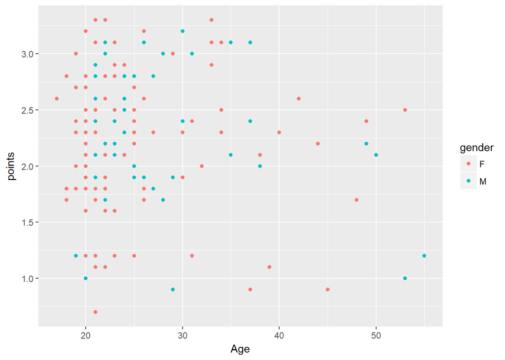

```r
library(ggplot2)

p1 <- ggplot(learning2014, aes(x = Age, y = points))
p1 <- ggplot(learning2014, aes (x = Age, y = points, col = gender))
p2 <- p1 + geom_point()
p2
```

```r
summary(learning2014$Age)
```

```
##    Min. 1st Qu.  Median    Mean 3rd Qu.    Max.
##   17.00   21.00   22.00   25.51   27.00   55.00
```

```r
summary(learning2014$points)
```

```
##    Min. 1st Qu.  Median    Mean 3rd Qu.    Max.
##   0.700   1.900   2.300   2.272   2.775   3.300
```

The summary of the variable *“Age”* shows that the minimum-age of the respondents is 17, the maximimum-age 55. The plot, thereby indicates that the majority of the respondents is to be found within the age-group of up to 30 years. The summary of the variable *points* displays that the respondent with the least points has 0.7, while the respondent with the highest points has 3.3. Furthermore, the plot indicates that the respondents with the higher points are up to 40 years old.

2. Relating Age with deep distinguished by gender

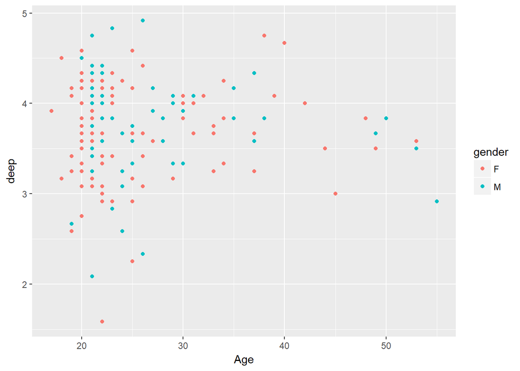

```r
library(ggplot2)

p1 <- ggplot(learning2014, aes(x = Age, y = deep))
p1 <- ggplot(learning2014, aes (x = Age, y = deep, col = gender))
p2 <- p1 + geom_point()
p2
```

```r
summary(learning2014$deep)
```

```
##    Min. 1st Qu.  Median    Mean 3rd Qu.    Max.
##   1.583   3.333   3.667   3.680   4.083   4.917
```

3. Relating Age with surf distinguished by gender

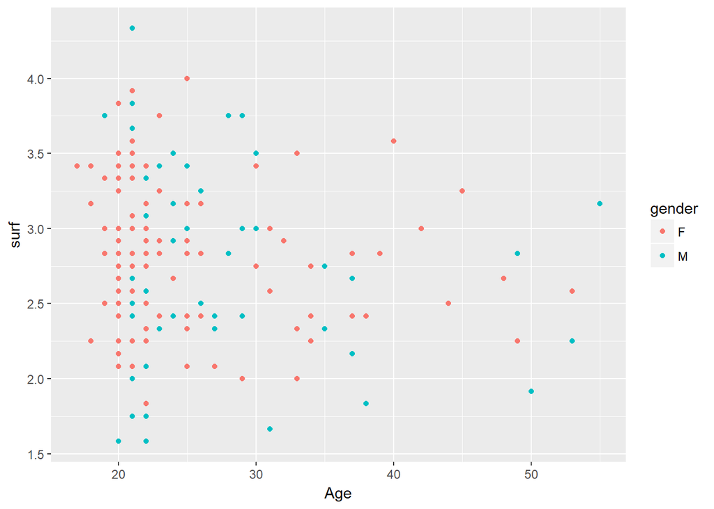

```r
library(ggplot2)

p1 <- ggplot(learning2014, aes(x = Age, y = surf))
p1 <- ggplot(learning2014, aes (x = Age, y = surf, col = gender))
p2 <- p1 + geom_point()
p2
```

```r
summary(learning2014$surf)
```

```
##    Min. 1st Qu.  Median    Mean 3rd Qu.    Max.
##   1.583   2.417   2.833   2.787   3.167   4.333
```

4. Relating Age with stra distinguished by gender

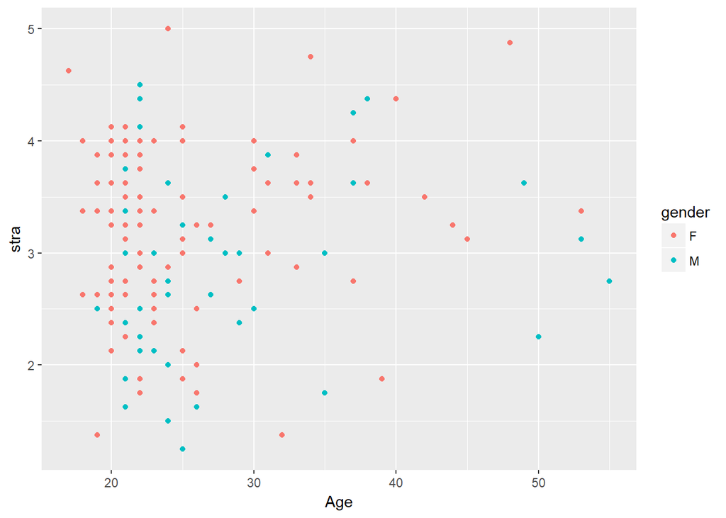

```r
library(ggplot2)

p1 <- ggplot(learning2014, aes(x = Age, y = stra))
p1 <- ggplot(learning2014, aes (x = Age, y = stra, col = gender))
p2 <- p1 + geom_point()
p2
```

```r
summary(learning2014$stra)
```

```
##    Min. 1st Qu.  Median    Mean 3rd Qu.    Max.
##   1.250   2.625   3.188   3.121   3.625   5.000
```

## Attempting multiple regression

With the next code I have attempted to undertake multiple regression with points as the target-variable, based on the variables “attitude”, “stra”, and “surf”, incl. the diagnostic plots:

```r
library(ggplot2)

my_model2 <- lm(points ~ attitude + stra + surf, data = learning2014)
summary(my_model2)
```

```
##
## Call:
## lm(formula = points ~ attitude + stra + surf, data = learning2014)
##
## Residuals:
##      Min       1Q   Median       3Q      Max
## -1.71550 -0.34346  0.05156  0.36401  1.08952
##
## Coefficients:
##             Estimate Std. Error t value Pr(>|t|)
## (Intercept)  1.10171    0.36837   2.991  0.00322 **
## attitude     0.33952    0.05741   5.913 1.93e-08 ***
## stra         0.08531    0.05416   1.575  0.11716
## surf        -0.05861    0.08014  -0.731  0.46563
## ---
## Signif. codes:  0 '***' 0.001 '**' 0.01 '*' 0.05 '.' 0.1 ' ' 1
##
## Residual standard error: 0.5296 on 162 degrees of freedom
## Multiple R-squared:  0.2074, Adjusted R-squared:  0.1927
## F-statistic: 14.13 on 3 and 162 DF,  p-value: 3.156e-08
```

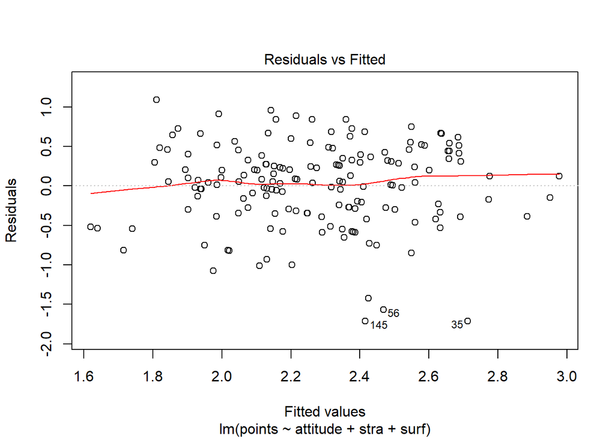

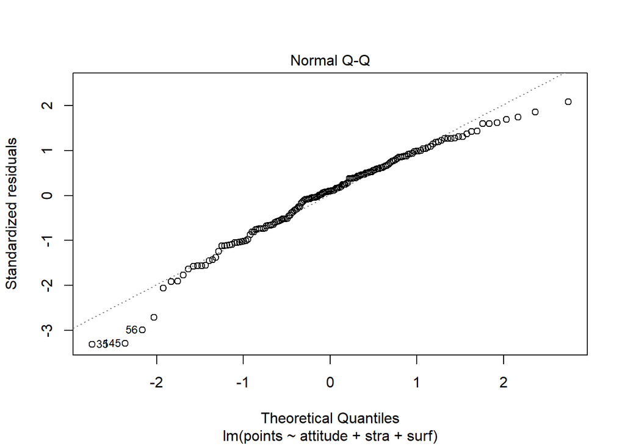

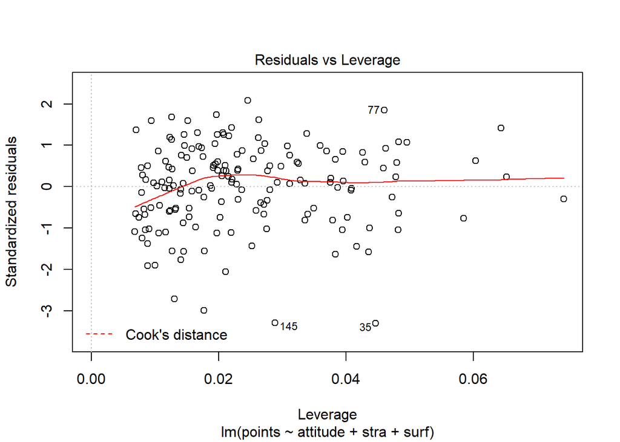

```r
plot(my_model2, which = c(1, 2, 5))
```

```r
?plot.lm
```

```
## starting httpd help server ... done
```

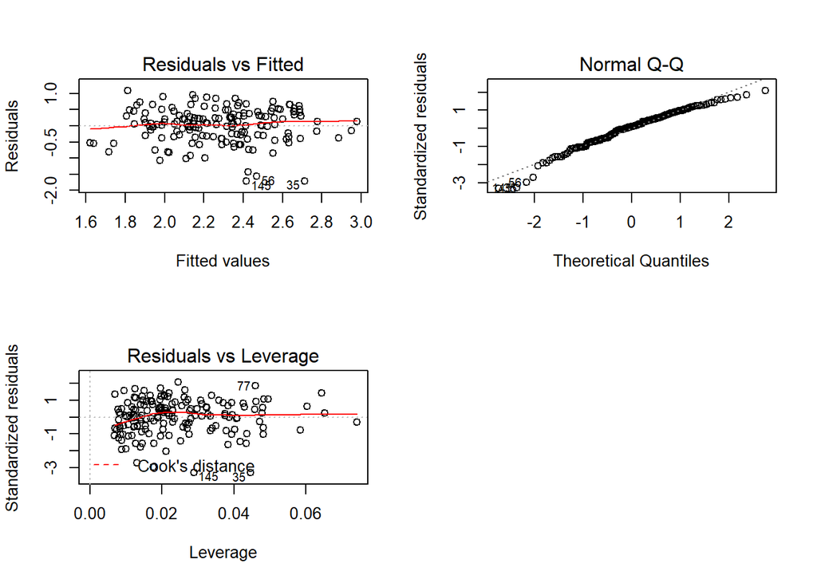

```r
par(mfrow = c(2,2))
plot(my_model2, which = c(1, 2, 5))
```